# OOPs(Object Oriented Programing in Python)

```python
a=4.5
```

```python
print(type(a))
```

```
<class 'float'>
```

```python
b=57
```

```python
print(type(b))
```

```
<class 'int'>
```

```python
c='Priya'
```

```python
print(type(c))
```

```
<class 'str'>
```

```python
d=False
```

```python
print(type(d))
```

```
<class 'bool'>
```

```python
dir(str)
```

```
['__add__',
 '__class__',
 '__contains__',
 '__delattr__',
 '__dir__',
 '__doc__',
 '__eq__',
 '__format__',
 '__ge__',
 '__getattribute__',
 '__getitem__',
 '__getnewargs__',
 '__getstate__',
 '__gt__',
 '__hash__',
 '__init__',
 '__init_subclass__',
 '__iter__',
 '__le__',
 '__len__',
 '__lt__',
 '__mod__',
 '__mul__',
 '__ne__',
 '__new__',
 '__reduce__',
 '__reduce_ex__',
 '__repr__',
 '__rmod__',
 '__rmul__',
 '__setattr__',
 '__sizeof__',
 '__str__',
 '__subclasshook__',
 'capitalize',
 'casefold',
 'center',
 'count',
 'encode',
 'endswith',
```

[output cut: 26 more lines]

```
 'rfind',
 'rindex',
 'rjust',
 'rpartition',
 'rsplit',
 'rstrip',
 'split',
 'splitlines',
 'startswith',
 'strip',
 'swapcase',
 'title',
 'translate',
 'upper',
 'zfill']
```

```python
#### Here  __function__  belongs to dunder function
```

## Functions written functionName : Dunder functions (Internal code of class)

It is a bad practice to use Dunder functions directly (it may affect internal coding of class)

```python
c.lower
```

```
<function str.lower()>
```

```python
c.lower()
```

```
'priya'
```

```python
c.upper()
```

```
'PRIYA'
```

# Dataframe Example

```python
import os
os.chdir('E:/Datasets/')
```

```python
import pandas as pd
df = pd.read_csv('50_Startups (1).csv')
df
```

|  | RND | ADMIN | MKT | STATE | PROFIT |
| --- | --- | --- | --- | --- | --- |
| 0 | 165349.20 | 136897.80 | 471784.10 | New York | 192261.83 |
| 1 | 162597.70 | 151377.59 | 443898.53 | California | 191792.06 |
| 2 | 153441.51 | 101145.55 | 407934.54 | Florida | 191050.39 |
| 3 | 144372.41 | 118671.85 | 383199.62 | New York | 182901.99 |
| 4 | 142107.34 | 91391.77 | 366168.42 | Florida | 166187.94 |
| 5 | 131876.90 | 99814.71 | 362861.36 | New York | 156991.12 |
| 6 | 134615.46 | 147198.87 | 127716.82 | California | 156122.51 |
| 7 | 130298.13 | 145530.06 | 323876.68 | Florida | 155752.60 |
| 8 | 120542.52 | 148718.95 | 311613.29 | New York | 152211.77 |
| 9 | 123334.88 | 108679.17 | 304981.62 | California | 149759.96 |
| 10 | 101913.08 | 110594.11 | 229160.95 | Florida | 146121.95 |
| 11 | 100671.96 | 91790.61 | 249744.55 | California | 144259.40 |
| 12 | 93863.75 | 127320.38 | 249839.44 | Florida | 141585.52 |
| 13 | 91992.39 | 135495.07 | 252664.93 | California | 134307.35 |
| 14 | 119943.24 | 156547.42 | 256512.92 | Florida | 132602.65 |
| 15 | 114523.61 | 122616.84 | 261776.23 | New York | 129917.04 |
| 16 | 78013.11 | 121597.55 | 264346.06 | California | 126992.93 |
| 17 | 94657.16 | 145077.58 | 282574.31 | New York | 125370.37 |
| 18 | 91749.16 | 114175.79 | 294919.57 | Florida | 124266.90 |
| 19 | 86419.70 | 153514.11 | 0.00 | New York | 122776.86 |
| 20 | 76253.86 | 113867.30 | 298664.47 | California | 118474.03 |
| 21 | 78389.47 | 153773.43 | 299737.29 | New York | 111313.02 |
| 22 | 73994.56 | 122782.75 | 303319.26 | Florida | 110352.25 |
| 23 | 67532.53 | 105751.03 | 304768.73 | Florida | 108733.99 |
| 24 | 77044.01 | 99281.34 | 140574.81 | New York | 108552.04 |
| 25 | 64664.71 | 139553.16 | 137962.62 | California | 107404.34 |
| 26 | 75328.87 | 144135.98 | 134050.07 | Florida | 105733.54 |
| 27 | 72107.60 | 127864.55 | 353183.81 | New York | 105008.31 |
| 28 | 66051.52 | 182645.56 | 118148.20 | Florida | 103282.38 |
| 29 | 65605.48 | 153032.06 | 107138.38 | New York | 101004.64 |
| 30 | 61994.48 | 115641.28 | 91131.24 | Florida | 99937.59 |
| 31 | 61136.38 | 152701.92 | 88218.23 | New York | 97483.56 |
| 32 | 63408.86 | 129219.61 | 46085.25 | California | 97427.84 |
| 33 | 55493.95 | 103057.49 | 214634.81 | Florida | 96778.92 |
| 34 | 46426.07 | 157693.92 | 210797.67 | California | 96712.80 |
| 35 | 46014.02 | 85047.44 | 205517.64 | New York | 96479.51 |
| 36 | 28663.76 | 127056.21 | 201126.82 | Florida | 90708.19 |
| 37 | 44069.95 | 51283.14 | 197029.42 | California | 89949.14 |
| 38 | 20229.59 | 65947.93 | 185265.10 | New York | 81229.06 |
| 39 | 38558.51 | 82982.09 | 174999.30 | California | 81005.76 |
| 40 | 28754.33 | 118546.05 | 172795.67 | California | 78239.91 |
| 41 | 27892.92 | 84710.77 | 164470.71 | Florida | 77798.83 |
| 42 | 23640.93 | 96189.63 | 148001.11 | California | 71498.49 |
| 43 | 15505.73 | 127382.30 | 35534.17 | New York | 69758.98 |
| 44 | 22177.74 | 154806.14 | 28334.72 | California | 65200.33 |
| 45 | 1000.23 | 124153.04 | 1903.93 | New York | 64926.08 |
| 46 | 1315.46 | 115816.21 | 297114.46 | Florida | 49490.75 |
| 47 | 0.00 | 135426.92 | 0.00 | California | 42559.73 |
| 48 | 542.05 | 51743.15 | 0.00 | New York | 35673.41 |
| 49 | 0.00 | 116983.80 | 45173.06 | California | 14681.40 |

```python
print(type(df))
```

```
<class 'pandas.core.frame.DataFrame'>
```

```python
df.shape
```

```
(50, 5)
```

```python
list(df.columns)
```

```
['RND', 'ADMIN', 'MKT', 'STATE', 'PROFIT']
```

```python
df.columns
```

```
Index(['RND', 'ADMIN', 'MKT', 'STATE', 'PROFIT'], dtype='object')
```

```python
df.index
```

```
RangeIndex(start=0, stop=50, step=1)
```

```python
list(df.index)
```

```
[0,
 1,
 2,
 3,
 4,
 5,
 6,
 7,
 8,
 9,
 10,
 11,
 12,
 13,
 14,
 15,
 16,
 17,
 18,
 19,
 20,
 21,
 22,
 23,
 24,
 25,
 26,
 27,
 28,
 29,
 30,
 31,
 32,
 33,
 34,
 35,
 36,
 37,
 38,
 39,
 40,
 41,
 42,
 43,
 44,
 45,
 46,
 47,
 48,
 49]
```

```python
df.dtypes
```

```
RND       float64
ADMIN     float64
MKT       float64
STATE      object
PROFIT    float64
dtype: object
```

## Functions / Methods in Class Dataframe

Methods which are used for advanced coding in python is known as functions in dataframe

```python
df.info()
```

```
<class 'pandas.core.frame.DataFrame'>
RangeIndex: 50 entries, 0 to 49
Data columns (total 5 columns):
 #   Column  Non-Null Count  Dtype
---  ------  --------------  -----
 0   RND     50 non-null     float64
 1   ADMIN   50 non-null     float64
 2   MKT     50 non-null     float64
 3   STATE   50 non-null     object
 4   PROFIT  50 non-null     float64
dtypes: float64(4), object(1)
memory usage: 2.1+ KB
```

```python
df.query('PROFIT>150000')
```

|  | RND | ADMIN | MKT | STATE | PROFIT |
| --- | --- | --- | --- | --- | --- |
| 0 | 165349.20 | 136897.80 | 471784.10 | New York | 192261.83 |
| 1 | 162597.70 | 151377.59 | 443898.53 | California | 191792.06 |
| 2 | 153441.51 | 101145.55 | 407934.54 | Florida | 191050.39 |
| 3 | 144372.41 | 118671.85 | 383199.62 | New York | 182901.99 |
| 4 | 142107.34 | 91391.77 | 366168.42 | Florida | 166187.94 |
| 5 | 131876.90 | 99814.71 | 362861.36 | New York | 156991.12 |
| 6 | 134615.46 | 147198.87 | 127716.82 | California | 156122.51 |
| 7 | 130298.13 | 145530.06 | 323876.68 | Florida | 155752.60 |
| 8 | 120542.52 | 148718.95 | 311613.29 | New York | 152211.77 |

```python
df.sort_values(by='ADMIN',ascending = False)
```

|  | RND | ADMIN | MKT | STATE | PROFIT |
| --- | --- | --- | --- | --- | --- |
| 28 | 66051.52 | 182645.56 | 118148.20 | Florida | 103282.38 |
| 34 | 46426.07 | 157693.92 | 210797.67 | California | 96712.80 |
| 14 | 119943.24 | 156547.42 | 256512.92 | Florida | 132602.65 |
| 44 | 22177.74 | 154806.14 | 28334.72 | California | 65200.33 |
| 21 | 78389.47 | 153773.43 | 299737.29 | New York | 111313.02 |
| 19 | 86419.70 | 153514.11 | 0.00 | New York | 122776.86 |
| 29 | 65605.48 | 153032.06 | 107138.38 | New York | 101004.64 |
| 31 | 61136.38 | 152701.92 | 88218.23 | New York | 97483.56 |
| 1 | 162597.70 | 151377.59 | 443898.53 | California | 191792.06 |
| 8 | 120542.52 | 148718.95 | 311613.29 | New York | 152211.77 |
| 6 | 134615.46 | 147198.87 | 127716.82 | California | 156122.51 |
| 7 | 130298.13 | 145530.06 | 323876.68 | Florida | 155752.60 |
| 17 | 94657.16 | 145077.58 | 282574.31 | New York | 125370.37 |
| 26 | 75328.87 | 144135.98 | 134050.07 | Florida | 105733.54 |
| 25 | 64664.71 | 139553.16 | 137962.62 | California | 107404.34 |
| 0 | 165349.20 | 136897.80 | 471784.10 | New York | 192261.83 |
| 13 | 91992.39 | 135495.07 | 252664.93 | California | 134307.35 |
| 47 | 0.00 | 135426.92 | 0.00 | California | 42559.73 |
| 32 | 63408.86 | 129219.61 | 46085.25 | California | 97427.84 |
| 27 | 72107.60 | 127864.55 | 353183.81 | New York | 105008.31 |
| 43 | 15505.73 | 127382.30 | 35534.17 | New York | 69758.98 |
| 12 | 93863.75 | 127320.38 | 249839.44 | Florida | 141585.52 |
| 36 | 28663.76 | 127056.21 | 201126.82 | Florida | 90708.19 |
| 45 | 1000.23 | 124153.04 | 1903.93 | New York | 64926.08 |
| 22 | 73994.56 | 122782.75 | 303319.26 | Florida | 110352.25 |
| 15 | 114523.61 | 122616.84 | 261776.23 | New York | 129917.04 |
| 16 | 78013.11 | 121597.55 | 264346.06 | California | 126992.93 |
| 3 | 144372.41 | 118671.85 | 383199.62 | New York | 182901.99 |
| 40 | 28754.33 | 118546.05 | 172795.67 | California | 78239.91 |
| 49 | 0.00 | 116983.80 | 45173.06 | California | 14681.40 |
| 46 | 1315.46 | 115816.21 | 297114.46 | Florida | 49490.75 |
| 30 | 61994.48 | 115641.28 | 91131.24 | Florida | 99937.59 |
| 18 | 91749.16 | 114175.79 | 294919.57 | Florida | 124266.90 |
| 20 | 76253.86 | 113867.30 | 298664.47 | California | 118474.03 |
| 10 | 101913.08 | 110594.11 | 229160.95 | Florida | 146121.95 |
| 9 | 123334.88 | 108679.17 | 304981.62 | California | 149759.96 |
| 23 | 67532.53 | 105751.03 | 304768.73 | Florida | 108733.99 |
| 33 | 55493.95 | 103057.49 | 214634.81 | Florida | 96778.92 |
| 2 | 153441.51 | 101145.55 | 407934.54 | Florida | 191050.39 |
| 5 | 131876.90 | 99814.71 | 362861.36 | New York | 156991.12 |
| 24 | 77044.01 | 99281.34 | 140574.81 | New York | 108552.04 |
| 42 | 23640.93 | 96189.63 | 148001.11 | California | 71498.49 |
| 11 | 100671.96 | 91790.61 | 249744.55 | California | 144259.40 |
| 4 | 142107.34 | 91391.77 | 366168.42 | Florida | 166187.94 |
| 35 | 46014.02 | 85047.44 | 205517.64 | New York | 96479.51 |
| 41 | 27892.92 | 84710.77 | 164470.71 | Florida | 77798.83 |
| 39 | 38558.51 | 82982.09 | 174999.30 | California | 81005.76 |
| 38 | 20229.59 | 65947.93 | 185265.10 | New York | 81229.06 |
| 48 | 542.05 | 51743.15 | 0.00 | New York | 35673.41 |
| 37 | 44069.95 | 51283.14 | 197029.42 | California | 89949.14 |

```python
df.groupby(by='STATE').mean()['PROFIT']
```

```
STATE
California    103905.175294
Florida       118774.024375
New York      113756.446471
Name: PROFIT, dtype: float64
```

```python
a =pd.Series(['a','b','c','d'], name='Example')
```

```python
a
```

```
0    a
1    b
2    c
3    d
Name: Example, dtype: object
```

```python
a.name
```

```
'Example'
```

```python
###in series 'O' means object
a.dtype
```

```
dtype('O')
```

```python
a
```

```
0    a
1    b
2    c
3    d
Name: Example, dtype: object
```

```python
type(a)
```

```
pandas.core.series.Series
```

```python
###series mein sirf row rehta hai
a.shape
```

```
(4,)
```

```python
a.index
```

```
RangeIndex(start=0, stop=4, step=1)
```

```python
a.sort_values(ascending=False)
```

```
3    d
2    c
1    b
0    a
Name: Example, dtype: object
```

# Creating user defined class

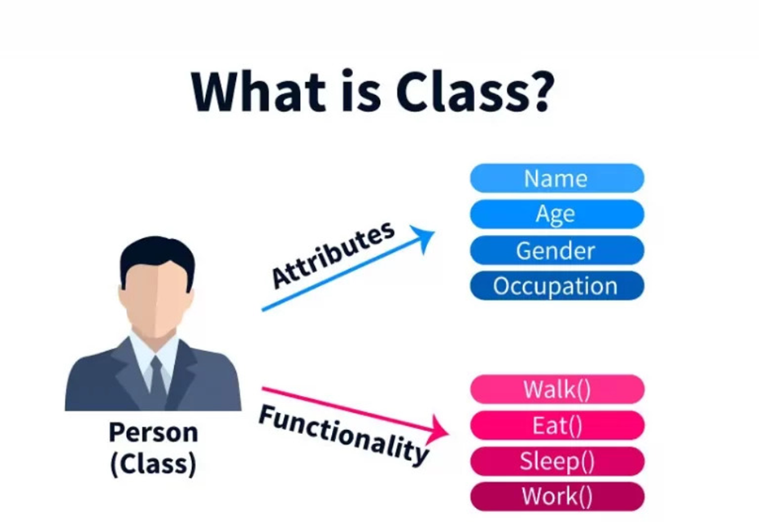

```python
class Person:
    """
    This class defines a Person
    """
    ###here __init__ is used as a constuctor
    ###self is always used in program
    def __init__(self, name, age, gender, occupation):

        self.name = name
        self.age = age
        self.gender = gender
        self.occupation = occupation

    def introduce(self):
        """
        This class introduce a person
        """
        print(f'Hi there myself {self.name}')
        print(f'I am {self.age} years old')
        print(f'I am a {self.gender}')
        print(f'I work as a {self.occupation}')

    def work(self, company):
        """
        This function talks about work of person
        """
        print(f'{self.name} works in {company}')
```

```python
p1 = Person('Priya',20,'Female','Data Scientist')
```

```python
p1
```

```
<__main__.Person at 0x1cbdb774390>
```

**main** means current file that is open

```python
print(type(p1))
```

```
<class '__main__.Person'>
```

```python
p1.name
```

```
'Priya'
```

```python
p1.age
```

```
20
```

```python
p1.gender
```

```
'Female'
```

```python
p1.occupation
```

```
'Data Scientist'
```

```python
p1.introduce()
```

```
Hi there myself Priya
I am 20 years old
I am a Female
I work as a Data Scientist
```

```python
help(Person)
```

```
Help on class Person in module __main__:

class Person(builtins.object)
 |  Person(name, age, gender, occupation)
 |  This class defines a Person
 |  Methods defined here:
 |  __init__(self, name, age, gender, occupation)
 |      Initialize self.  See help(type(self)) for accurate signature.
 |  introduce(self)
 |      This class introduce a person
 |  work(self, company)
 |      This function talks about work of person
 |  ----------------------------------------------------------------------
 |  Data descriptors defined here:
 |  __dict__
 |      dictionary for instance variables (if defined)
 |  __weakref__
 |      list of weak references to the object (if defined)
```

```python
p1.work('ETLhive')
```

```
Priya works in ETLhive
```

```python
p1.work('TCS')
```

```
Priya works in TCS
```

```python
p2 = Person(occupation='HR', name='Aditi', age=27, gender='Female')
```

```python
p1.name
```

```
'Priya'
```

```python
p2.name
```

```
'Aditi'
```

```python
p2.age
```

```
27
```

```python
p2.occupation
```

```
'HR'
```

```python
p2.gender
```

```
'Female'
```

```python
type(p2)
```

```
__main__.Person
```

```python
print(type(p2))
```

```
<class '__main__.Person'>
```

```python
p2.introduce()
```

```
Hi there myself Aditi
I am 27 years old
I am a Female
I work as a HR
```

```python
p2.work('Infosys')
```

```
Aditi works in Infosys
```

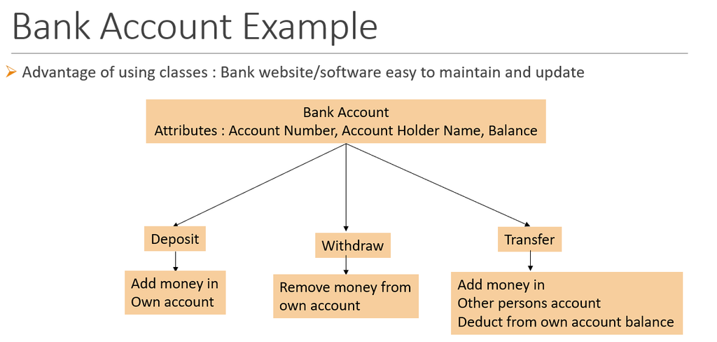

```python
class Account:

    def __init__(self, ac_no, name , balance):
        self.ac_no = ac_no
        self.name = name
        self.balance = balance

    def deposit(self, amt):
        self.balance = self.balance + amt
        print(f'Money of {amt} INR is credited into : {self.ac_no} ')
        print(f'Current Balance is : {self.balance} INR')

    def withdraw(self, amt):
        if self.balance >=  amt:
            self.balance = self.balance - amt
            print(f'Money of {amt} INR is debited from your account : {self.ac_no} ')
            print(f'Current Balance is : {self.balance} INR')
        else:
            print(f'Insufficient balance in your : {self.ac_no}')
            print(f'Current Balance is : {self.balance} INR')

    def transfer(self, tr_ac , amt):
        if self.balance >= amt:
            self.balance = self.balance - amt
            tr_ac.balance = tr_ac.balance + amt
            print(f'Money of {amt} INR is debited from your account  : {self.ac_no} to {tr_ac.ac_no}')
            print(f'Current Balance is : {self.balance} INR')
        else:
            print(f'Insufficient balance in your : {self.ac_no}')
            print(f'Current Balance is : {self.balance} INR')
```

```python
ac1 = Account(123,'SP',500000)
```

```python
ac1
```

```
<__main__.Account at 0x1cbdb7d3b90>
```

```python
ac1.ac_no
```

```
123
```

```python
ac1.name
```

```
'SP'
```

```python
ac1.balance
```

```
500000
```

```python
ac1.deposit(1500)
```

```
Money of 1500 INR is credited into : 123
Current Balance is : 501500 INR
```

```python
ac1.withdraw(10000)
```

```
Money of 10000 INR is debited from your account : 123
Current Balance is : 491500 INR
```

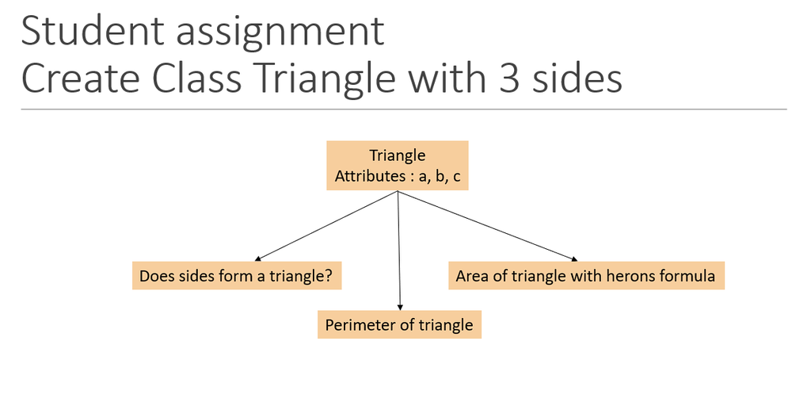

1:- Formation of triangle : Sum of 2 sides should be greater than 3rd

2:- Perimeter : Sum of all sides of triangle (a+b+c)

3:- Area of triangle : A=sqrt(s∗(s−a)*(s−b∗(s−c))

4:- s=(a+b+c)/2

```python
class Triangle:

    def __init__(self,a , b, c):
        self.a = a
        self.b = b
        self.c = c

    def isTriangle(self):
        a = self.a
        b = self.b
        c = self.c
        if (a+b>c) and (a+c>b) and (b+c>a):
            tr = True
        else:
            tr = False
        return tr

    def perimeter(self):
        if self.isTriangle() == True:
            p = self.a + self.b +self.c
        else:
            p= None
            print(f'Sides {self.a} , {self.b} , {self.c} do NOT form a Triangle')
        return p



    def area(self):
        if self.isTriangle()==True:
            s = self.perimeter()/2
            a = (s*(s-self.a)*(s-self.b)*(s-self.c))**(1/2)
        else:
            a = None
            print(f'The sides {self.a}, {self.b} and {self.c} DO NOT FORM a Triangle')
        return a
```

```python
t1= Triangle(1,2,3)
```

```python
t1.a
```

```
1
```

```python
t1.b
```

```
2
```

```python
t1.c
```

```
3
```

```python
t1.isTriangle
```

```
<bound method Triangle.isTriangle of <__main__.Triangle object at 0x000001CBDB7DD210>>
```

```python
t1.isTriangle()
```

```
False
```

```python
t1.perimeter()
```

```
Sides 1 , 2 , 3 do NOT form a Triangle
```

```python
t1.area()
```

```
The sides 1, 2 and 3 DO NOT FORM a Triangle
```

```python
t3 = Triangle(12, 13, 14)
```

```python
t3
```

```
<__main__.Triangle at 0x1cbdb754910>
```

```python
t3.perimeter()
```

```
39
```

```python
t3.area()
```

```
72.30793524918272
```

```python
t3.isTriangle()
```

```
True
```

## Polymorphism in functions

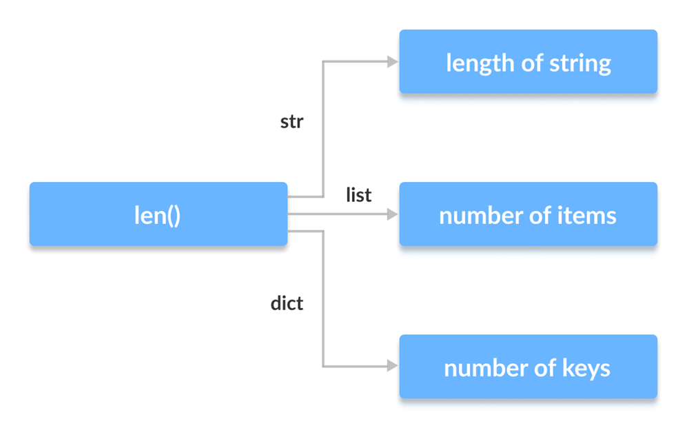

```python
s = 'ETLHive'
(type(s))
```

```
str
```

```python
len(s)
```

```
7
```

```python
a = ['a', 1, 2, 11.5, True, 'Example']
type(a)
```

```
list
```

```python
len(a)
```

```
6
```

```python
dct = {101 : 'Priya',
       102 : 'Riya',
       103 : 'Jiya'}
```

```python
type(dct)
```

```
dict
```

```python
len(dct)
```

```
3
```

```python
import os
os.chdir('E:/Datasets/')
```

```python
import pandas as pd
df = pd.read_csv('Cars93.csv')
df.head()
```

|  | id | Manufacturer | Model | Type | Min.Price | Price | Max.Price | MPG.city | MPG.highway | AirBags | ... | Passengers | Length | Wheelbase | Width | Turn.circle | Rear.seat.room | Luggage.room | Weight | Origin | Make |
| --- | --- | --- | --- | --- | --- | --- | --- | --- | --- | --- | --- | --- | --- | --- | --- | --- | --- | --- | --- | --- | --- |
| 0 | 1 | Acura | Integra | Small | 12.9 | 15.9 | 18.8 | 25 | 31 | None | ... | 5 | 177 | 102 | 68 | 37 | 26.5 | 11.0 | 2705 | non-USA | Acura Integra |
| 1 | 2 | Acura | Legend | Midsize | 29.2 | 33.9 | 38.7 | 18 | 25 | Driver & Passenger | ... | 5 | 195 | 115 | 71 | 38 | 30.0 | 15.0 | 3560 | non-USA | Acura Legend |
| 2 | 3 | Audi | 90 | Compact | 25.9 | 29.1 | 32.3 | 20 | 26 | Driver only | ... | 5 | 180 | 102 | 67 | 37 | 28.0 | 14.0 | 3375 | non-USA | Audi 90 |
| 3 | 4 | Audi | 100 | Midsize | 30.8 | 37.7 | 44.6 | 19 | 26 | NaN | ... | 6 | 193 | 106 | 70 | 37 | 31.0 | 17.0 | 3405 | non-USA | Audi 100 |
| 4 | 5 | BMW | 535i | Midsize | 23.7 | 30.0 | 36.2 | 22 | 30 | Driver only | ... | 4 | 186 | 109 | 69 | 39 | 27.0 | 13.0 | 3640 | non-USA | BMW 535i |

5 rows × 28 columns

```python
df.shape
```

```
(93, 28)
```

```python
len(df)
```

```
93
```

## Polymorphism in Operators

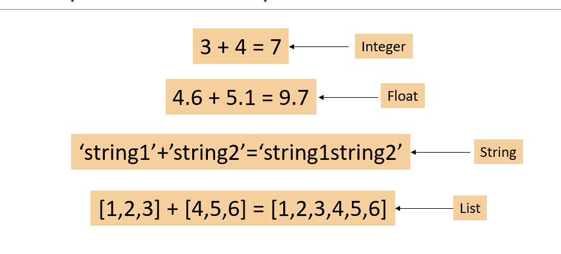

```python
3 + 7
```

```
10
```

```python
4.5 + 7.1
```

```
11.6
```

```python
'ETLHive' + 'Class'
```

```
'ETLHiveClass'
```

```python
[1, 2, 3, 4] + [5, 7, 9]
```

```
[1, 2, 3, 4, 5, 7, 9]
```

```python
'Example'*3
```

```
'ExampleExampleExample'
```

```python
[1, 8, 11]*5
```

```
[1, 8, 11, 1, 8, 11, 1, 8, 11, 1, 8, 11, 1, 8, 11]
```

## Polymorphism in class

defines that child class has the same method name as parent class has..

poly means 'two' forms

```python
class India:

    def capital(self):
        print('New Delhi is capital of India')

    def language(self):
        print('Hindi is widely spoken language in India')
```

```python
class USA:

    def capital(self):
        print('Washington D.C. is capital of USA')

    def language(self):
        print('English is widely spoken in USA')
```

```python
class France:

    def capital(self):
        print('Capital of France is Paris')

    def language(self):
        print('French is widely spoken in France')
```

```python
c1 = India()
c2 = USA()
c3 = France()
```

```python
type(c1)
```

```
__main__.India
```

```python
type(c2)
```

```
__main__.USA
```

```python
type(c3)
```

```
__main__.France
```

```python
c1.capital()
```

```
New Delhi is capital of India
```

```python
c2.capital()
```

```
Washington D.C. is capital of USA
```

```python
c3.capital()
```

```
Capital of France is Paris
```

```python
c1.language()
```

```
Hindi is widely spoken language in India
```

```python
c2.language()
```

```
English is widely spoken in USA
```

```python
c3.language()
```

```
French is widely spoken in France
```

```python
for i in [c1, c2, c3]:
    print(type(i))
    i.capital()
    i.language()
    print("\n*****************************************************************")
```

[output not shown]

## Diffrent classes circle, rectangle

```python
from math import pi
```

```python
pi
```

```
3.141592653589793
```

```python
class Circle:

    def __init__(self, r):
        self.r = r

    def area(self):
        a = pi*(self.r**2)
        return a
```

```python
class Rectangle:

    def __init__(self, l, w):
        self.l = l
        self.w = w

    def area(self):
        a = self.l*self.w
        return a
```

```python
c1 = Circle(7)
```

```python
r1 = Rectangle(5, 7)
```

```python
type(c1)
```

```
__main__.Circle
```

```python
type(r1)
```

```
__main__.Rectangle
```

```python
c1.area()
```

```
153.93804002589985
```

```python
r1.area()
```

```
35
```

```python
c2 = Circle(17)
r2 = Rectangle(10, 15)
```

```python
for i in [c1, r1, c2, r2]:
    print(type(i))
    print(f'Area : {i.area():.2f} sq.units')
    print('\n==============================================\n')
```

```
<class '__main__.Circle'>
Area : 153.94 sq.units

==============================================

<class '__main__.Rectangle'>
Area : 35.00 sq.units

==============================================

<class '__main__.Circle'>
Area : 907.92 sq.units

==============================================

<class '__main__.Rectangle'>
Area : 150.00 sq.units

==============================================
```

## Triangle example with decorator

Decorator - Outside

```python
 def triangleCheck(func):
        def wrapper(self, *args, **kwargs):
            if self.isTriangle()==True:
                f = func(self, *args, **kwargs)
            else:
                f = None
                print(f'The sides {self.a}, {self.b} and {self.c} DO NOT FORM a Triangle')
            return f
        return wrapper
```

```python
@triangleCheck
class Triangle:

    def __init__(self, a, b, c):
        self.a = a
        self.b = b
        self.c = c

    def isTriangle(self):
        a = self.a
        b = self.b
        c = self.c
        if (a+b>c) and (b+c>a) and (c+a)>b:
            tr = True
        else:
            tr = False
        return tr

    @triangleCheck
    def perimeter(self):
        p = self.a + self.b + self.c
        return p

    @triangleCheck
    def area(self):
        s = self.perimeter()/2
        a = (s*(s-self.a)*(s-self.b)*(s-self.c))**(1/2)
        return a
```

```python
tr2 = Triangle(12, 13, 14)
```

```
---------------------------------------------------------------------------
AttributeError                            Traceback (most recent call last)
Cell In[125], line 1
----> 1 tr2 = Triangle(12, 13, 14)

Cell In[123], line 3, in triangleCheck.<locals>.wrapper(self, *args, **kwargs)
      2 def wrapper(self, *args, **kwargs):
----> 3     if self.isTriangle()==True:
      4         f = func(self, *args, **kwargs)
      5     else:

AttributeError: 'int' object has no attribute 'isTriangle'
```

```python
tr.isTriangle()
```

```python
tr.perimeter()
```

```python
tr2 = Triangle(3, 4, 11)
```

```python
tr2.perimeter()
```

```python
tr2.area()
```

# Inheritance in Class

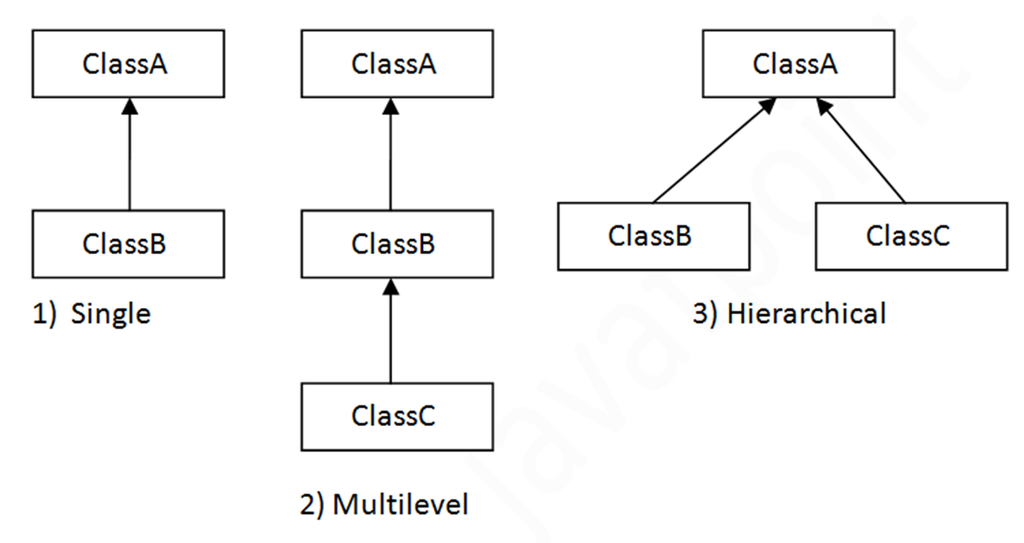

```python
### Parent class(super class)
class Person ():
    def __init__(self ,name , age):
        self.name = name
        self.age = age

    def introduce(self):
        print(f'Hi all , My name is {self.name}!!')
        print(f'I am {self.age} years old.')
```

```python
p1 = Person('Priya',20)
```

```python
p1
```

```python
p1.age
```

```python
p1.name
```

```python
p1.introduce()
```

```python
type(p1)
```

```python
# Child class - Inherit all the properties and methods from Person class
class Employee(Person):
    def __init__(self, name, age, company, occupation):
        super().__init__(name , age)
        self.company = company
        self.occupation = occupation

    def work(self):
        print(f'I work in {self.company} as a {self.occupation}')
```

```python
p2=Employee('Priya',20,'TCS','Data Scientist')
```

```python
p2.work
```

```python
p2.work()
```

```python
p2.introduce()
```

```python
p1.introduce()
p2.work()
```

```python
class Person ():
    def __init__(self ,name , age):
        self.name = name
        self.age = age

    def introduce(self):
        print(f'Hi all , My name is {self.name}!!')
        print(f'I am {self.age} years old.')
```

```python
class Employee(Person):
    def __init__(self, name, age, company, occupation):
        super().__init__(name , age)
        self.company = company
        self.occupation = occupation

    def work(self):
        super().introduce()
        print(f'I work in {self.company} as a {self.occupation}')
```

```python
p3 = Person('Jiya' , 20)
```

```python
p4 = Employee('Jiya',20,'TCS','Data Scientist')
```

```python
p4.work()
```

# Multilevel Inheritance

1. Parent Class
2. Child class
3. class

```python
class Employee:

    def __init__(self, emp_id, name):
        self.emp_id = emp_id
        self.name = name

    def get_employee_info(self):
        print(f'Employee Id : {self.emp_id} , Name : {self.name}')
```

```python
class Manager(Employee):

    def __init__(self, emp_id, name, department):
        super().__init__(emp_id, name)
        self.department = department

    def get_manager_info(self):
        super().get_employee_info()
        print(f'Department : {self.department}')
```

```python
class ProjectManager(Manager):

    def __init__(self, emp_id, name, department, project):
        super().__init__(emp_id, name, department)
        self.project = project

    def get_project_manager_info(self):
        super().get_manager_info()
        print(f'Project : {self.project}')
```

```python
e1 = Employee(103,'Rohan')
```

```python
e1
```

```python
type(e1)
```

```python
e1.name
```

```python
e1.emp_id
```

```python
e1.get_employee_info()
```

```python
m1 = Manager(102, 'Raman', 'Purchase')
```

```python
type(m1)
```

```python
m1.get_manager_info()
```

```python
pm1 = ProjectManager(101, 'Rahul', 'Mechanical', 'JLR')
```

```python
type(pm1)
```

```python
pm1.name
```

```python
pm1.department
```

```python
pm1.project
```

```python
pm1.get_project_manager_info()
```

# Hierarchical Inheritance

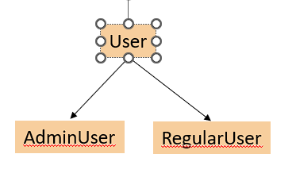

```python
class user:

    def __init__(self, username, email_id):
        self.username = username
        self.email_id = email_id

    def get_user_info(self):
        print(f'Username : {self.username}, email_id : {self.email_id}')
```

```python
class admin(user):

    def __init__(self, username, email_id, access):
        super().__init__(username, email_id)
        self.access = access

    def get_admin_acess(self):
        print(f'Access Rights : {self.access}')
```

```python
class RegularUser(user):

    def __init__(self, username, email_id, subscription_type):
        super().__init__(username, email_id)
        self.subscription_type = subscription_type

    def get_reg_user_subscription(self):
        print(f'Subscription type : {self.subscription_type}')
```

```python
u1 = user('priya1', 'priya@gmail.com')
```

```python
type(u1)
```

```python
u1.username
```

```python
u1.email_id
```

```python
a1 = admin('prashant23', 'prashant@etlhive.com', 'Full')
```

```python
a1.username
```

```python
a1.email_id
```

```python
a1.access
```

```python
a1.get_user_info()
```

```python
a1.get_admin_acess()
```

```python
r1 = RegularUser('aditim1', 'aditi@gmail.com', 'free')
```

```python
type(r1)
```

```python
r1.username
```

```python
r1.email_id
```

```python
r1.subscription_type
```

```python
r1.get_user_info()
```

```python
r1.get_reg_user_subscription()
```

# Exception Handling

## Syntax errors (Mistake in typing of code)

```python
print'hi priya'
```

```python
print('Hi All')
```

```python
n = 23
if n%2==0:
print('number is even')
```

### Exception : Operations that do not make sense causes exceptions in python

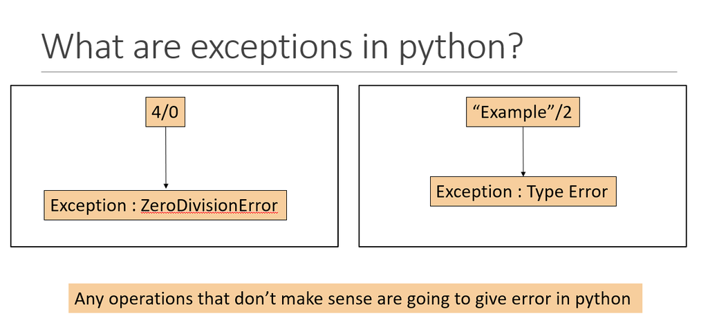

```python
4.5/0
```

```python
'abc'/3
```

```python
float('14.34')
```

```python
float('abc')
```

## Create a function to divide 2 numbers

```python
def divide_nums():
    num = float(input("Enter numerator : "))
    den = float(input("Enter denominator : "))
    n = num / den
    return n
```

```python
divide_nums()
```

```python
a = divide_nums()
9/3
```

```python
a
```

```python
divide_nums()
print("Calculation complete")
```

```python
divide_nums()
print(3*5)
```

### Handling above errors with try except handling

```python
def div_exp():
    try:
        num = float(input("Enter numerator : "))
        den = float(input("Enter denominator : "))
        div = num / den
        return div
    except ZeroDivisionError:
        print("Denominator cant be 0")
    except ValueError:
        print("Please enter numbers only, alphabets are not allowed for division ")
```

```python
div_exp()
```

```python
div_exp()
```

```python
print(div_exp())
print('Hello Priya')
```

```python
print(div_exp())
print('Calculation complete')
```

# Square root of negative numbers

```python
import math
```

```python
math.sqrt(3)
```

```python
math.sqrt(100)
```

```python
math.sqrt(-3)
```

```python
###u can call a function inside a function
def sqr_root():
    try:
        n = float(input("Enter a number : "))
        import math
        s = math.sqrt(n)
        return s
    except Exception as e:
        print (f'Exception occured :{e}')
```

```python
sqr_root()
```

```python
sqr_root()
```

```python
sqr_root()
```

```python
a= sqr_root()
print('Calculation Complete')
```

```python
a
```

```python
print(sqr_root())
print('Hello Hello')
```

```python
print(sqr_root())
print('Hello Hello')
```

```python
print(sqr_root())
print(3*4)
```

```python
sqr_root()
print(3*4)
```

# Raising own exception

1:- age cannot be negative

2:- age cannot be more than 110

```python
age = int(input("Please enter your age :"))
if age <=0 or age>=110:
    raise ValueError("Please enter age between 0 and 110")
else:
    print(f"Valid age is entered {age} years ")
```

```python
age = int(input("Please enter your age :"))
if age <=0 or age>=110:
    raise ValueError("Please enter age between 0 and 110")
else:
    print(f"Valid age is entered {age} years ")
```

```python
age = int(input("Please enter your age :"))
if age <=0 or age>=110:
    raise ValueError("Please enter age between 0 and 110")
else:
    print(f"Valid age is entered {age} years ")
```

## Handling above exception

```python
try:
    age = int(input("Please enter your age :"))
    if age <=0 or age>=110:
        raise ValueError("Please enter age between 0 and 110")
    else:
         print(f"Valid age is entered {age} years ")
except Exception as e:
    print("Exception ocured :{e}")
```

```python
try:
    age = int(input("Please enter your age :"))
    if age <=0 or age>=110:
        raise ValueError("Please enter age between 0 and 110")
    else:
         print(f"Valid age is entered {age} years ")
except Exception as e:
    print(f"Exception ocured :{e}")
```

```python
try:
    age = int(input("Please enter your age :"))
    if age <=0 or age>=110:
        raise ValueError("Please enter age between 0 and 110")
    else:
         print(f"Valid age is entered {age} years ")
except Exception as e:
    print(f"Exception ocured :{e}")
```

```python
try:
    age = int(input("Please enter your age :"))
    if age <=0 or age>=110:
        raise ValueError("Please enter age between 0 and 110")
    else:
         print(f"Valid age is entered {age} years ")
except Exception as e:
    print(f"Exception ocured :{e}")
```

## Try Except Finally block

1:- Code will execute try block

2:- if any error/exception occurs it will go to except block

3:- finally block will always execute

```python
def calculate_sqr_root():
    try:
        n = float(input("Enter a number : "))
        import math
        s = math.sqrt(n)
        return s
    except Exception as e:
        print (f'Exception occured :{e}')
    finally:
        print("Fianlly block is always executed")
```

```python
calculate_sqr_root()
```

```python
print(calculate_sqr_root())
```

```python
print(calculate_sqr_root())
99/3
```

```python
print(calculate_sqr_root())
```

```python
print(calculate_sqr_root())
```

# Multithreading

[figure not shown]

```python
import time
```

```python
time.sleep(2)
print('Hello Priya')
```

##### %%time -- ye pata chalta hai ki kitna time laga execution ke liye

```python
%%time
time.sleep(2)
print('Hello Priya')
```

```python
def print_message(message):
    time.sleep(2)
    print(f'Message: {message}')
```

5! = 5x4x3x2x1

4! = 4x3x2x1

```python
list(range(1,10))
```

```python
list(range(1,11))
```

```python
def factorial(n):
    time.sleep(2)
    p = 1
    for i in range(1, n+1):
        p = p*i
    print(f'Factorial for given number {n} is {p}')
```

## Normal without multithreading

```python
%%time
print_message('Welcome to Multithreading class')
```

```python
factorial(5)
```

```python
%%time
print_message('Hello World')
factorial(5)
```

```python
import threading
```

```python
print_thread = threading.Thread(target = print_message , args = ('Hello World',))
factorial_thread = threading.Thread(target = factorial , args =(10,))
```

```python
%%time
# Start all threads simultaneously
print_thread.start()
factorial_thread.start()

# Wait for all threads to finish
print_thread.join()
factorial_thread.join()
```

## 1 function but mutiple values

```python
def square(n):
    """
    This function returns square of a given number
    """
    s = n*n
    print(f'Square of a given number {n} is {s}')
    return s
```

```python
square(6)
```

```python
square([1,2,3])
```

```python
b = [1,2,3,4,5]
c = []
for i in b:
    s = square(i)
    c.append(s)
```

```python
b
```

```python
c
```

```python
s
```

```python
for i in b:
    print(i)
```

# Multithreading

```python
###creating multiple threads
threads = []
for i in b:
    thread = threading.Thread(target = square , args =(i,))
    thread.start()
    threads.append(thread)

for thread in threads:
    thread.join()
```

```python
### creating multiple threads
threads = []
for i in range (1, 1000):
    thread = threading.Thread(target=square, args =(i,))
    threads.append(thread)
```

```python
%%time
for thread in threads:
    thread.start()

for thread in threads:
    thread.join()
```

```python
%%time
for i in range(1, 1000):
    s = square(i)
```

## Downloading multiple files simulatneously

```python
url = "https://raw.githubusercontent.com/utkarshg1/mlproject_regression/main/artifacts/data.csv"
```

```python
filename = url.split('/')[-1]
```

```python
filename
```

```python
import os
os.chdir('E:/Multithreading/')
```

```python
from urllib.request import urlretrieve
def download_file(url):
    filename = url.split('/')[-1]
    print(f'Downloading {filename}.......')
    urlretrieve(url, filename)
    print(f'{filename} Download Complete')
```

```python
url
```

```python
download_file(url)
```

```python
urls = ["https://raw.githubusercontent.com/utkarshg1/mlproject_regression/main/artifacts/data.csv",
"https://raw.githubusercontent.com/utkarshg1/mlproject_regression/main/artifacts/test.csv",
"https://raw.githubusercontent.com/utkarshg1/mlproject_regression/main/artifacts/train.csv"]
```

```python
for i in urls:
    download_file(i)
```

## Multithreading download

```python
urls
```

```python
threads = []
for i in urls:
    thread = threading.Thread (target = download_file , args = (i,))
    thread.start()
    threads.append(thread)

for thread in threads:
    thread.join()
```

# Numpy Arrays

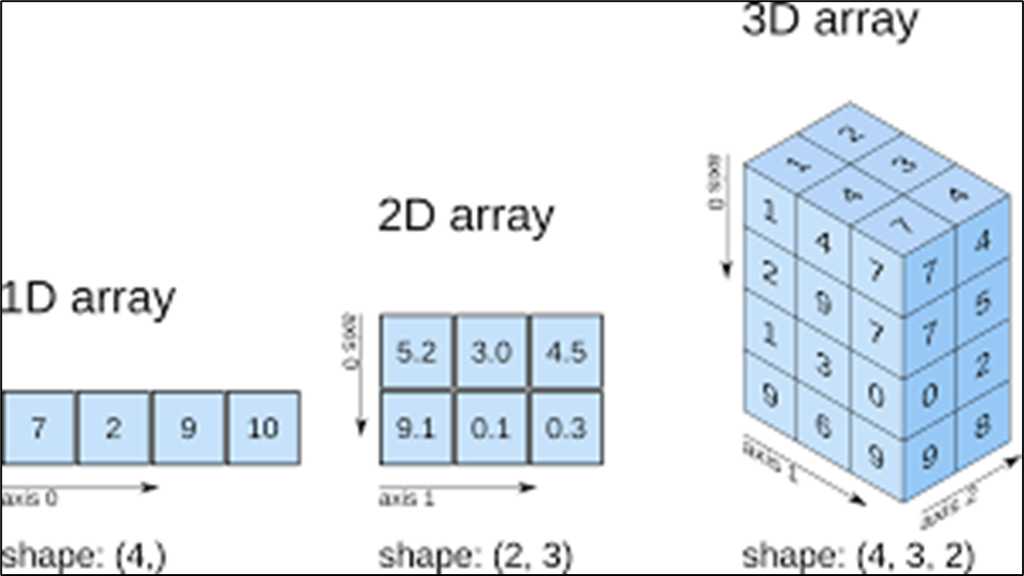

```python
import numpy as np
```

```python
a1 = np.array([1,2,3,8,9])
```

```python
a1
```

```
array([1, 2, 3, 8, 9])
```

```python
a1.shape
```

```
(5,)
```

```python
a1.ndim
```

```
1
```

```python
a1[3]
```

```
8
```

```python
a1[2:4]
```

```
array([3, 8])
```

# 2d array

```python
a2 = np.array([[1,4,5],
               [5,7,3]])
```

```python
a2
```

```
array([[1, 4, 5],
       [5, 7, 3]])
```

```python
a2.shape
```

```
(2, 3)
```

```python
a2.ndim
```

```
2
```

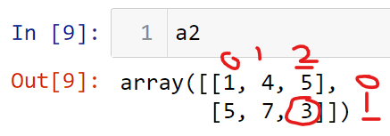

```python
a2[1,2]
```

```
3
```

```python
a2[0,1]
```

```
4
```

```python
a2[0,2]
```

```
5
```

```python
a2[:,1:3]
```

```
array([[4, 5],
       [7, 3]])
```

```python
a2[:,0:3]
```

```
array([[1, 4, 5],
       [5, 7, 3]])
```

```python
a2[:,0:1]
```

```
array([[1],
       [5]])
```

```python
a2[0:1,:]
```

```
array([[1, 4, 5]])
```

```python
a2[0:2, 0:2]
```

```
array([[1, 4],
       [5, 7]])
```

# 3d array

```python
a3 = np.array([[[4, 5, 6],
                [11, 10, 9]],

               [[11, 13, 15],
                [6, 7, 8]]])
```

```python
a3
```

```
array([[[ 4,  5,  6],
        [11, 10,  9]],

       [[11, 13, 15],
        [ 6,  7,  8]]])
```

```python
a3.ndim
```

```
3
```

```python
a3.shape
```

```
(2, 2, 3)
```

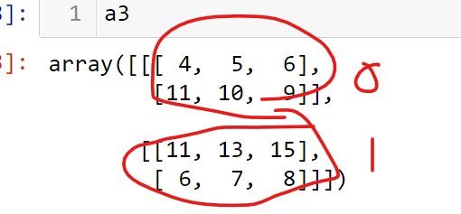

```python
a3[0]
```

```
array([[ 4,  5,  6],
       [11, 10,  9]])
```

```python
a3[1]
```

```
array([[11, 13, 15],
       [ 6,  7,  8]])
```

```python
a3[1, 1, 1]
```

```
7
```

```python
a3[0, 0, 2]
```

```
6
```

```python
a3[0, 1, 1:3]
```

```
array([10,  9])
```

```python
a3[1, :, 0:2]
```

```
array([[11, 13],
       [ 6,  7]])
```

```python
a4 = np.array([[4, 5, 6, 7],
               [1, 2, 3, 4],
               [11, 13, 15, 14]])
```

```python
a4.ndim
```

```
2
```

```python
a4.shape
```

```
(3, 4)
```

# a4[row_index, column_index]

```python
a4
```

```
array([[ 4,  5,  6,  7],
       [ 1,  2,  3,  4],
       [11, 13, 15, 14]])
```

```python
a4[1, 2]
```

```
3
```

```python
a4[2, 1]
```

```
13
```

```python
a4[:, 1:3]
```

```
array([[ 5,  6],
       [ 2,  3],
       [13, 15]])
```

```python
a4[1:3, :]
```

```
array([[ 1,  2,  3,  4],
       [11, 13, 15, 14]])
```

```python
a4[1:3, 1:4]
```

```
array([[ 2,  3,  4],
       [13, 15, 14]])
```

# List vs Array

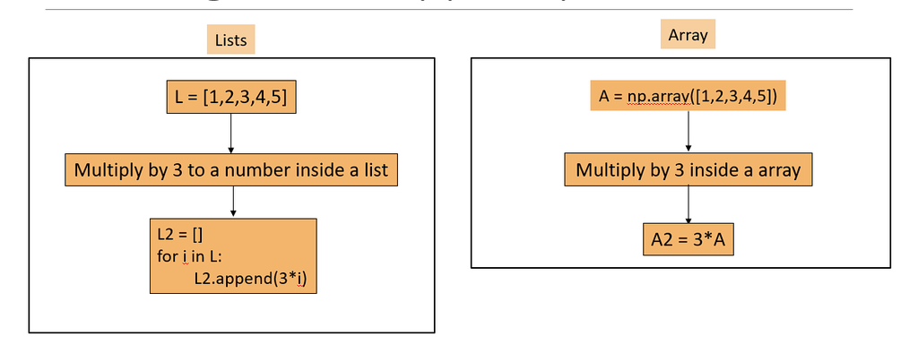

```python
A = [1,2,3,4,5]
A
```

```
[1, 2, 3, 4, 5]
```

```python
A*2
```

```
[1, 2, 3, 4, 5, 1, 2, 3, 4, 5]
```

```python
A*3
```

```
[1, 2, 3, 4, 5, 1, 2, 3, 4, 5, 1, 2, 3, 4, 5]
```

```python
type(A)
```

```
list
```

```python
B = []
for i in A:
    B.append(i*3)
```

```python
B
```

```
[3, 6, 9, 12, 15]
```

```python
A
```

```
[1, 2, 3, 4, 5]
```

```python
A2 = np.array(A)
A2
```

```
array([1, 2, 3, 4, 5])
```

```python
type(A2)
```

```
numpy.ndarray
```

```python
B2 = 3 * A2
```

```python
B2
```

```
array([ 3,  6,  9, 12, 15])
```

```python
B3 = 2*A2 + 3
```

```python
B3
```

```
array([ 5,  7,  9, 11, 13])
```

```python
A2
```

```
array([1, 2, 3, 4, 5])
```

```python
B4 = A2**2
```

```python
B4
```

```
array([ 1,  4,  9, 16, 25])
```

```python
B5 = A2**(1/2)
```

```python
B5
```

```
array([1.        , 1.41421356, 1.73205081, 2.        , 2.23606798])
```

## Numpy arrays all mathematical operations can be performed without for loop.

Numpy array are much faster compared to list for mathematical operation

## Getting product of elements inside list vs array

```python
C = [4,5,6,7]
```

```python
C
```

```
[4, 5, 6, 7]
```

```python
4*5*6*7
```

```
840
```

```python
p =1
for i in C:
    p = p*i
```

```python
p
```

```
840
```

```python
C2 = np.array(C)
```

```python
C2
```

```
array([4, 5, 6, 7])
```

```python
type(C2)
```

```
numpy.ndarray
```

```python
pr = np.prod(C2)
```

```python
pr
```

```
840
```

```python
S = np.sum(C2)
S
```

```
22
```

```python
M = np.mean(C2)
M
```

```
5.5
```

```python
22/4
```

```
5.5
```

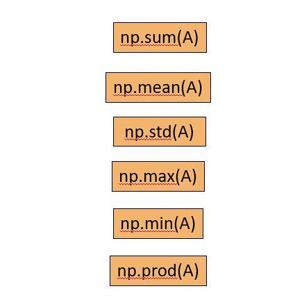

```python
C2
```

```
array([4, 5, 6, 7])
```

```python
np.max(C2)
```

```
7
```

```python
np.min(C2)
```

```
4
```

```python
np.std(C2)
```

```
1.118033988749895
```

```python
np.median(C2)
```

```
5.5
```

## Generating data through numpy

```python
range(3 , 17, 2)
```

```
range(3, 17, 2)
```

```python
list(range(3,17,2))
```

```
[3, 5, 7, 9, 11, 13, 15]
```

```python
list(range(0.1, 5.7, 0.3))
```

```
---------------------------------------------------------------------------
TypeError                                 Traceback (most recent call last)
Cell In[222], line 1
----> 1 list(range(0.1, 5.7, 0.3))

TypeError: 'float' object cannot be interpreted as an integer
```

list function mein float ki value use nhi hhoti h

```python
a = np.arange(0.1 , 6 ,0.2)
```

```python
a
```

```
array([0.1, 0.3, 0.5, 0.7, 0.9, 1.1, 1.3, 1.5, 1.7, 1.9, 2.1, 2.3, 2.5,
       2.7, 2.9, 3.1, 3.3, 3.5, 3.7, 3.9, 4.1, 4.3, 4.5, 4.7, 4.9, 5.1,
       5.3, 5.5, 5.7, 5.9])
```

# Linspace function

#### np.linspace(start, stop, divisions)

[figure not shown]

```python
d = np.linspace(2, 10, 5)
d
```

```
array([ 2.,  4.,  6.,  8., 10.])
```

```python
e = np.linspace(1, 10, 20)
e
```

```
array([ 1.        ,  1.47368421,  1.94736842,  2.42105263,  2.89473684,
        3.36842105,  3.84210526,  4.31578947,  4.78947368,  5.26315789,
        5.73684211,  6.21052632,  6.68421053,  7.15789474,  7.63157895,
        8.10526316,  8.57894737,  9.05263158,  9.52631579, 10.        ])
```

```python
len(e)
```

```
20
```

```python
(10-1)/(20-1)
```

```
0.47368421052631576
```

## Random numbers generation

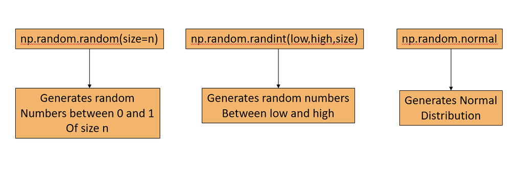

```python
a = np.random.random(size = 20)
a
```

```
array([0.26119213, 0.73980256, 0.2286276 , 0.80697944, 0.36935447,
       0.09763564, 0.90500579, 0.34170817, 0.38333169, 0.50875522,
       0.8333098 , 0.40938442, 0.69116075, 0.65392044, 0.20949408,
       0.51508805, 0.55969644, 0.04466678, 0.22373272, 0.67187655])
```

remember:- jitne baar exeute karoge wo random numbers jaise 0 se 1 ke bich mein koi bhi number aur agar tumko random number jitne bar execute karte wo change nhi karna to fir ek seed naam ka function hai jisko use karke tum random number fix kar sakte ho

## For repitability you can fix a random seed

```python
np.random.seed(34)
b = np.random.random(20)
b
```

```
array([0.03856168, 0.78010046, 0.09270376, 0.63289269, 0.01389085,
       0.93615854, 0.42657438, 0.25308645, 0.18996531, 0.41482463,
       0.01342061, 0.64847278, 0.86936875, 0.6090357 , 0.80799282,
       0.82651133, 0.27168333, 0.83647644, 0.28254136, 0.1383086 ])
```

Now u can see baar baar execute karne par bhi change nhi hore numbers

# Generating integers

```python
dice = np.random.randint(low = 1,high = 7,size =200)
dice
```

```
array([3, 1, 5, 6, 5, 5, 6, 1, 2, 1, 4, 4, 3, 1, 4, 6, 1, 3, 2, 4, 3, 5,
       5, 3, 2, 5, 6, 5, 4, 1, 2, 5, 2, 2, 1, 5, 1, 6, 1, 1, 5, 4, 1, 5,
       1, 4, 2, 3, 3, 4, 2, 5, 6, 2, 5, 2, 5, 3, 3, 2, 1, 4, 4, 1, 4, 2,
       2, 6, 6, 5, 2, 5, 1, 2, 6, 1, 1, 5, 1, 4, 2, 5, 6, 3, 3, 4, 6, 5,
       3, 5, 4, 3, 6, 6, 6, 5, 3, 4, 6, 4, 3, 2, 2, 6, 2, 3, 3, 1, 4, 2,
       1, 5, 1, 4, 3, 6, 5, 5, 5, 5, 3, 4, 4, 1, 3, 5, 6, 1, 3, 3, 2, 4,
       3, 5, 2, 1, 5, 3, 2, 3, 2, 2, 5, 2, 6, 3, 5, 3, 6, 2, 1, 2, 6, 6,
       2, 3, 2, 5, 6, 4, 6, 3, 5, 4, 6, 5, 2, 3, 1, 5, 4, 3, 5, 3, 5, 5,
       1, 1, 3, 5, 4, 4, 4, 6, 5, 5, 3, 1, 1, 6, 1, 2, 1, 5, 5, 4, 5, 6,
       5, 3])
```

```python
###same agar fix karna hai to
np.random.seed(50)
dice2 = np.random.randint(low =1,high = 7, size=200)
dice2
```

```
array([1, 1, 4, 6, 2, 5, 6, 6, 6, 3, 3, 5, 4, 5, 4, 3, 3, 5, 4, 2, 6, 3,
       2, 1, 4, 4, 3, 2, 4, 4, 3, 5, 4, 3, 5, 1, 4, 3, 3, 1, 4, 1, 6, 6,
       1, 4, 3, 4, 5, 1, 4, 6, 5, 5, 1, 3, 4, 1, 6, 4, 3, 6, 4, 2, 6, 2,
       6, 5, 4, 6, 1, 4, 6, 6, 5, 2, 5, 5, 5, 5, 6, 5, 4, 4, 1, 6, 1, 5,
       4, 4, 4, 3, 3, 1, 5, 1, 6, 3, 5, 6, 1, 5, 5, 3, 3, 2, 3, 1, 4, 4,
       4, 4, 2, 2, 6, 1, 4, 4, 6, 3, 4, 1, 1, 1, 3, 3, 4, 2, 2, 6, 3, 6,
       6, 5, 2, 5, 2, 2, 4, 1, 3, 1, 3, 2, 1, 5, 3, 5, 4, 2, 6, 6, 4, 1,
       3, 1, 1, 4, 5, 3, 6, 5, 6, 1, 6, 5, 4, 4, 1, 2, 4, 5, 4, 5, 2, 4,
       5, 1, 5, 6, 6, 2, 6, 6, 5, 1, 4, 6, 2, 6, 4, 3, 4, 5, 3, 3, 1, 6,
       6, 1])
```

# Normal distribution

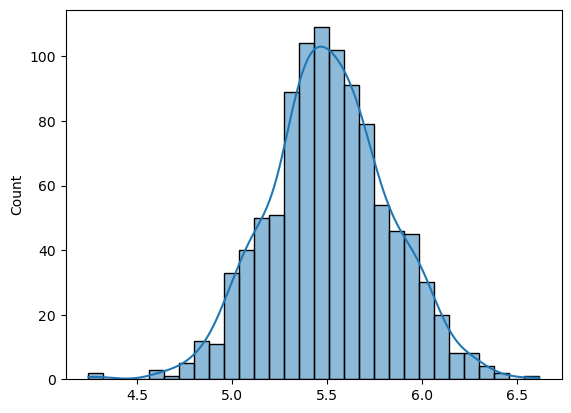

```python
heights = np.random.normal(loc = 5.5 , scale= 1/3 , size=1000)
import seaborn as sns
sns.histplot(heights,kde=True)
```

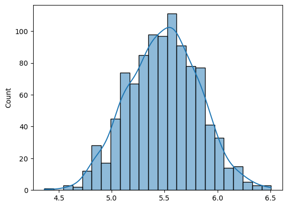

```python
np.random.seed(41)
heights = np.random.normal(loc=5.5, scale=1/3, size=1000)
import seaborn as sns
sns.histplot(heights, kde=True)
```

```python
dir(np)
```

```
['ALLOW_THREADS',
 'AxisError',
 'BUFSIZE',
 'CLIP',
 'ComplexWarning',
 'DataSource',
 'ERR_CALL',
 'ERR_DEFAULT',
 'ERR_IGNORE',
 'ERR_LOG',
 'ERR_PRINT',
 'ERR_RAISE',
 'ERR_WARN',
 'FLOATING_POINT_SUPPORT',
 'FPE_DIVIDEBYZERO',
 'FPE_INVALID',
 'FPE_OVERFLOW',
 'FPE_UNDERFLOW',
 'False_',
 'Inf',
 'Infinity',
 'MAXDIMS',
 'MAY_SHARE_BOUNDS',
 'MAY_SHARE_EXACT',
 'ModuleDeprecationWarning',
 'NAN',
 'NINF',
 'NZERO',
 'NaN',
 'PINF',
 'PZERO',
 'RAISE',
 'RankWarning',
 'SHIFT_DIVIDEBYZERO',
 'SHIFT_INVALID',
 'SHIFT_OVERFLOW',
 'SHIFT_UNDERFLOW',
 'ScalarType',
 'Tester',
 'TooHardError',
```

[output cut: 544 more lines]

```
 'unwrap',
 'use_hugepage',
 'ushort',
 'vander',
 'var',
 'vdot',
 'vectorize',
 'version',
 'void',
 'vsplit',
 'vstack',
 'where',
 'who',
 'zeros',
 'zeros_like']
```

```python
len(dir(np))
```

```
599
```

# Mathematical functions

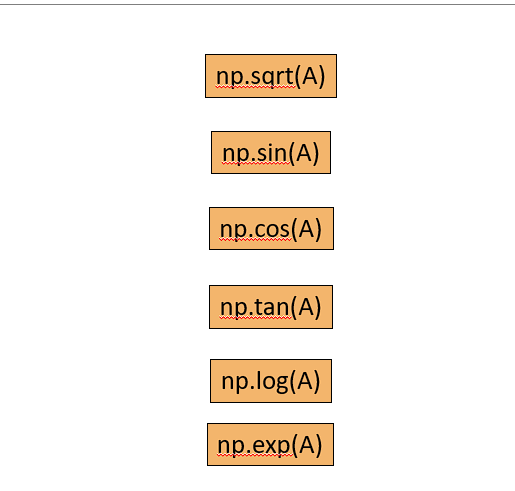

```python
E = np.array([1, 4, 7, 11, 13])
```

```python
E
```

```
array([ 1,  4,  7, 11, 13])
```

```python
np.sqrt(E)
```

```
array([1.        , 2.        , 2.64575131, 3.31662479, 3.60555128])
```

```python
np.log(E)
```

```
array([0.        , 1.38629436, 1.94591015, 2.39789527, 2.56494936])
```

```python
np.tan(E)
```

```
array([   1.55740772,    1.15782128,    0.87144798, -225.95084645,
          0.46302113])
```

```python
np.sin(E)
```

```
array([ 0.84147098, -0.7568025 ,  0.6569866 , -0.99999021,  0.42016704])
```

```python
np.exp(E)
```

```
array([2.71828183e+00, 5.45981500e+01, 1.09663316e+03, 5.98741417e+04,
       4.42413392e+05])
```

```python
2.598378
```

```
2.598378
```